# Comparing Omernik L2 Ecoregions and DOI regions for coding eSTZs

sagesteppe

2025-03-15

1. The number of units for labeling, DOI are limited to 12, how many L2 are there?
- Too many ecoregions will be *relatively* hard for people to remember, because they are abbreviated.
2. How contiguous are the L2 regions? Many polygons per region may negate their utility.
- The goal of this labeling schema isn’t to perfectly convey *where* a region covers, it’s to let people choose the relevant file quickly.

```r
library(sf)
library(tidyverse)
```

```r
doi <- st_read('../data/DOI_12_Unified_Regions.gpkg', quiet = T) |>
  select(DOI_NUM = REG_NUM, DOI_NAME = REG_NAME)
om <- st_read('../data/Omernik_L2_Ecoregions.gpkg', quiet = T) |>
  select(NA_L2CODE, NA_L2NAME) |>
  filter(NA_L2NAME != 'WATER')

st_agr(doi) <- 'constant'
st_agr(om) <- 'constant'
```

For the purposes of this exploratory investigation, we will restrict the focus to US and territories. However, we should keep in mind a couple things about the use of ecoregions which would be neglected by this approach: 1) Omernik ecoregions cover the entirety of North America. This makes them an obvious choice for collaborations between these nations. 2) World Wildlife Fund ecoregions are actually global, making them a true choice for international collaborations. Note that however, I can not speak to the quality of these for plants and whenever I have done analysis in South America I have used data products developed by other researchers or local government agencies.

## Compare the number of ecoregions and DOI regions for the US & Territories

First we will intersect the omernik region to the DOI regions.

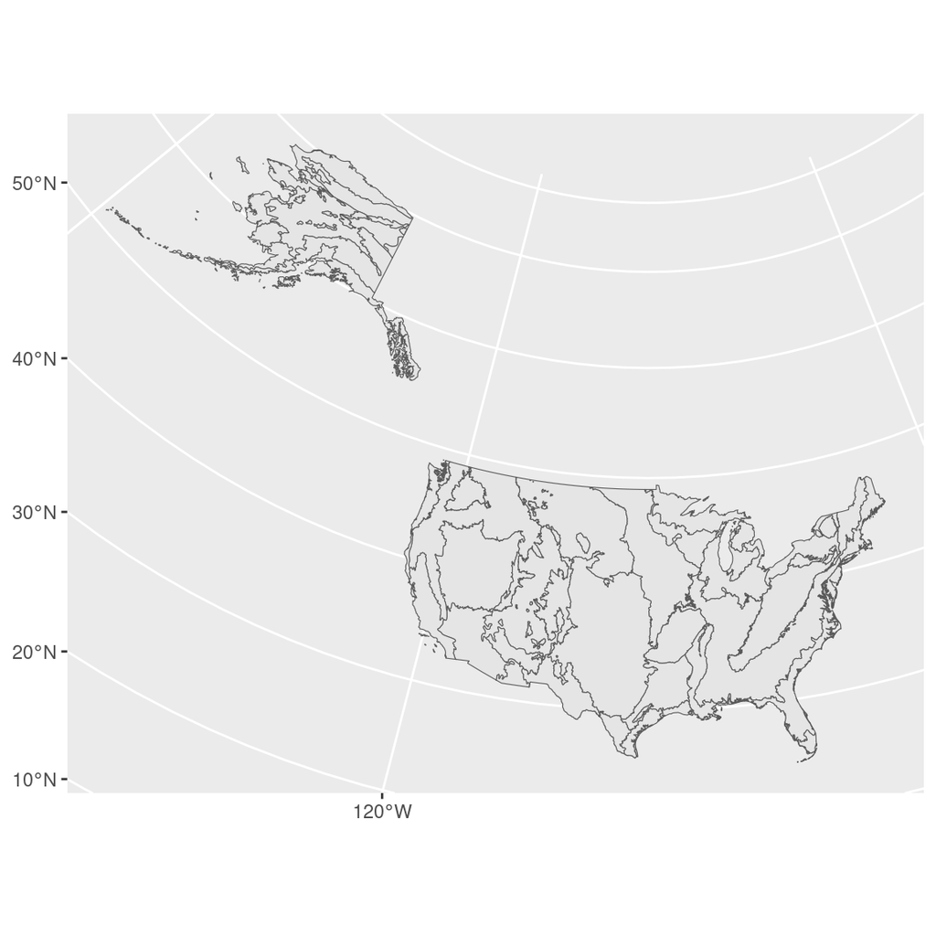

```r
om <- st_intersection(om, st_union(doi))

ggplot() +
  geom_sf(data = om)
```

```r
length(table(om$NA_L2NAME))
```

```
[1] 25
```

```r
table(om$NA_L2NAME)
```

```
                               ALASKA BOREAL INTERIOR
                                                    1
                                        ALASKA TUNDRA
                                                   63
                                   ATLANTIC HIGHLANDS
                                                    7
                                    BOREAL CORDILLERA
                                                   15
                                  BROOKS RANGE TUNDRA
                                                    1
                                   CENTRAL USA PLAINS
                                                   20
                                         COLD DESERTS
                                                    4
                                           EVERGLADES
                                                   92
                             MARINE WEST COAST FOREST
                                                  211
                             MEDITERRANEAN CALIFORNIA
                                                   20
MISSISSIPPI ALLUVIAL AND SOUTHEAST USA COASTAL PLAINS
                                                  617
                                    MIXED WOOD PLAINS
                                                  202
                                    MIXED WOOD SHIELD
                                                   38
                   OZARK/OUACHITA-APPALACHIAN FORESTS
                                                    9
                      SOUTH CENTRAL SEMIARID PRAIRIES
                                                    2
                              SOUTHEASTERN USA PLAINS
                                                   18
                                     TAIGA CORDILLERA
                                                    1
                      TAMAULIPAS-TEXAS SEMIARID PLAIN
                                                    1
                                   TEMPERATE PRAIRIES
                                                    1
                        TEXAS-LOUISIANA COASTAL PLAIN
                                                   24
                                 UPPER GILA MOUNTAINS
                                                   10
                                         WARM DESERTS
                                                    2
                       WEST-CENTRAL SEMIARID PRAIRIES
                                                    2
                                   WESTERN CORDILLERA
                                                   25
                        WESTERN SIERRA MADRE PIEDMONT
                                                    1
```

From a raw count perspective there are 25 L2 region for 10 DOI regions (this excludes Puerto Rico and Hawaii, which are not covered by the Omernik system). Obviously those are many more regions to codify and for a practicioner to try and remember. However, even if eSTZs ‘catch on’ in the East, I think this is a disingenious count. Basically, I know that a few of these regions are really small, and their chances of ending up in the region coding name part of a file name are very low.

We will remove a few of these very small regions and see what the count looks like at the end. Feel free to poke around with the map, or just look in a GUI or at this pdf link, https://dmap-prod-oms-edc.s3.us-east-1.amazonaws.com/ORD/Ecoregions/cec_na/NA_LEVEL_II.pdf.

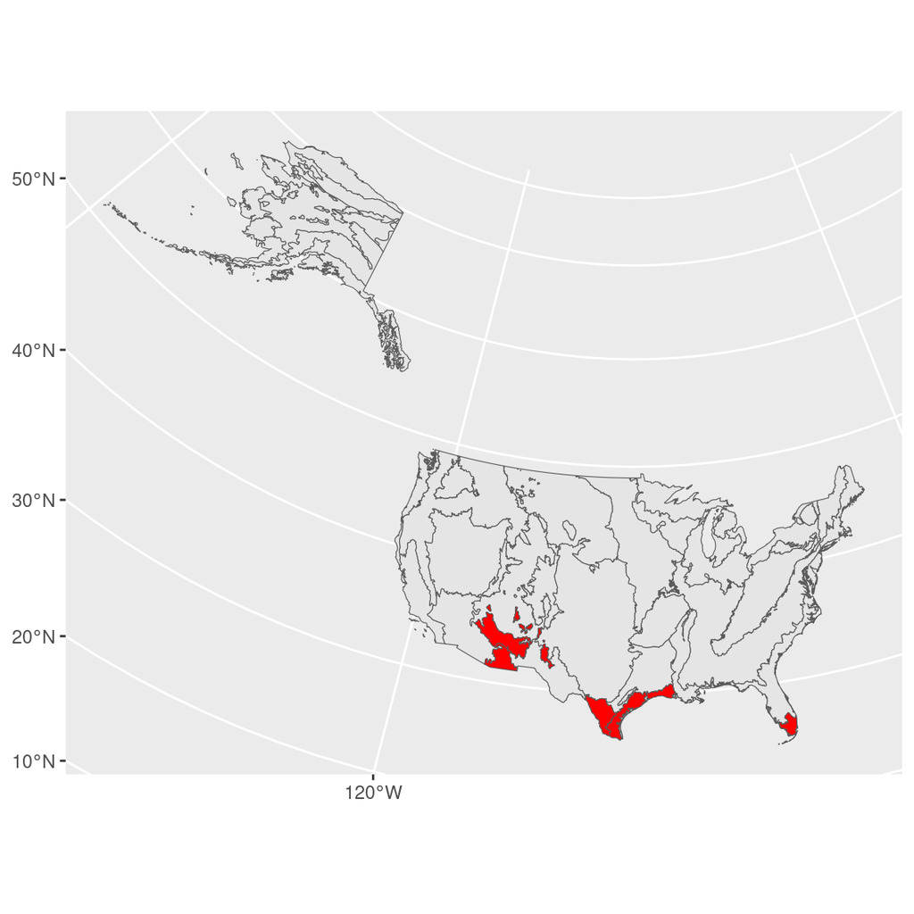

```r
small_oms <- c(
  'EVERGLADES',
  'UPPER GILA MOUNTAINS',
  'WESTERN SIERRA MADRE PIEDMONT',
  'TAMAULIPAS-TEXAS SEMIARID PLAIN',
  'TEXAS-LOUISIANA COASTAL PLAIN'
 # 'MISSISSIPPI ALLUVIAL AND SOUTHEAST USA COASTAL PLAINS' whoops definitely keep this.
)

small_oms <- filter(om, NA_L2NAME %in% small_oms) # save a copy to map them.
om <- filter(om, ! NA_L2NAME %in% unique(small_oms$NA_L2NAME))

ggplot() +
  geom_sf(data = om) +
  geom_sf(data = small_oms, fill = 'red')
```

These leaves us with 20 L2 Omernik Ecoregions to 10 DOI regions. Unfortunately those are still a lot of codes to remember and use. However, it could be worth it! Let’s take a look at how well these compare to DOI regions.

## Contiguity of L2 ecoregions

First we will cast all of the L2 region to ensure that we are counting adjacent areas (weird things occasionally happen with mapping which ‘splits’ adjacent areas into different polygons).

```r
patches <- om |>
  group_by(NA_L2NAME) |>
  summarize(geom = st_union(geom)) |>
  st_cast('MULTIPOLYGON') |>
  st_cast('POLYGON')

# ok that resulted in more pieces, which is not unexpected as many of these
# were multipolgyons. but I think this might be a little disingenuous.
# let's toss tiny pieces.
areas <- units::set_units(st_area(patches), 'acre')

# 1000 only got it down to 585, which seems biased against reviewer 1.
# let's go to 10k which is 278...
# OK rhode island is about 1 million acres - let's use that instead.
patches <- patches[areas > units::set_units(1e6, 'acre'),]
# that returns 54 patches, it is a bit difficult for me to justify going much bigger
# than the smallest US state.
```

```r
table(patches$NA_L2NAME)
```

```
                               ALASKA BOREAL INTERIOR
                                                    1
                                        ALASKA TUNDRA
                                                    6
                                   ATLANTIC HIGHLANDS
                                                    4
                                    BOREAL CORDILLERA
                                                    5
                                  BROOKS RANGE TUNDRA
                                                    1
                                   CENTRAL USA PLAINS
                                                    1
                                         COLD DESERTS
                                                    2
                             MARINE WEST COAST FOREST
                                                    9
                             MEDITERRANEAN CALIFORNIA
                                                    1
MISSISSIPPI ALLUVIAL AND SOUTHEAST USA COASTAL PLAINS
                                                    2
                                    MIXED WOOD PLAINS
                                                    4
                                    MIXED WOOD SHIELD
                                                    2
                   OZARK/OUACHITA-APPALACHIAN FORESTS
                                                    2
                      SOUTH CENTRAL SEMIARID PRAIRIES
                                                    2
                              SOUTHEASTERN USA PLAINS
                                                    2
                                     TAIGA CORDILLERA
                                                    1
                                   TEMPERATE PRAIRIES
                                                    1
                                         WARM DESERTS
                                                    2
                       WEST-CENTRAL SEMIARID PRAIRIES
                                                    1
                                   WESTERN CORDILLERA
                                                    5
```

These are quite a few non-contiguous patches, which to me totally makes sense and I support it. However, the goal of the file naming is simply to give people an idea of which file to open, and these are pretty bad for that because they vary so much in space, and oftentimes go on for so long.

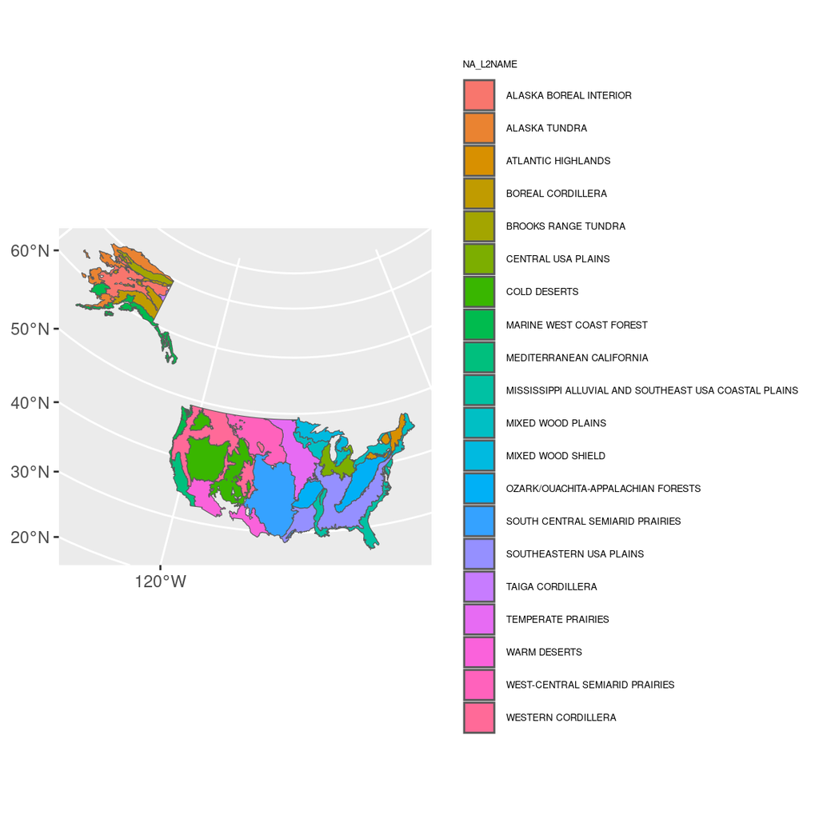

OK, so these are them. Note they are difficult to plot because their are still so many levels, so colours kind of fade out. Unfortunately I think these actually are a bit of a step back from DOI regions. For plants of the sagebrush biome we pretty much just end up with ‘Cold Desert’, for products from the Columbia Plateau, Great Basin, and Colorado Plateau. Unfortunately these products generally do not actually span the L2 regions, they are restricted by funding to subsets so this seems kind of weird. The Western forests are just a massive blob, and I suppose I am not seeing what we gain by splitting across the plains.

## Other random thoughts

A few regions are very different, California-Great Basin being the most stark example, and the Upper Colorado Basin being four wildly different areas in my mind We think the current naming suggestions is appropriate because the overturn in species between some of these areas are very high. In other words, the California floristic province species do not ‘spill’ into the Great Basin *that much* in my experience, so once a user has the species in mind, they should be able to cleave the area in their minds. A similar process should occur throughout the other regions, and this is why we opted for up to two naming elements. The products tend to be split between the Colorado Plateau, and the Great Basin currently. Likely due to funding mechanisms, this would result in us just having duplicate starting names: e.g. ‘Cold_desert-’ which could only be split by the second region, which in this case would probably be ‘Western Cordillera’ for both. This makes it very difficult for the L2 approach to work.

Hawaii is not covered by the Omernik ecoregions. However, I do not think eSTZs will ‘catch’ on there, and the zoning would be intuitively obvious for most of those taxa. It’s good to write this down for discussion purposes, but I think this is a moot point. It seems that the same process is happening for Puerto Rico, but again moot.